# Risk Factor Analysis

## Outcome Variable

**Outcome Variable:** stunted

## Predictor Variables

**Intervention Variable:** nhh

**Adjustment Set:**

- arm
- W_mage
- meducyrs
- feducyrs
- hhwealth_quart
- W_mhtcm
- W_mwtkg
- W_mbmi
- W_nrooms
- cleanck
- impfloor
- impsan
- safeh20
- delta_W_mage
- delta_meducyrs
- delta_feducyrs
- delta_hhwealth_quart
- delta_W_mhtcm
- delta_W_mwtkg
- delta_W_mbmi
- delta_W_nrooms
- delta_cleanck
- delta_impfloor
- delta_impsan
- delta_safeh20

## Stratifying Variables

The analysis was stratified on these variable(s):

- agecat
- studyid
- country

## Data Summary

| agecat | studyid | country | nhh | stunted | n_cell | n |
| --- | --- | --- | --- | --- | --- | --- |
| Birth | ki1000108-IRC | INDIA | 3 or less | 0 | 51 | 388 |
| Birth | ki1000108-IRC | INDIA | 3 or less | 1 | 3 | 388 |
| Birth | ki1000108-IRC | INDIA | 4-5 | 0 | 128 | 388 |
| Birth | ki1000108-IRC | INDIA | 4-5 | 1 | 22 | 388 |
| Birth | ki1000108-IRC | INDIA | 6-7 | 0 | 89 | 388 |
| Birth | ki1000108-IRC | INDIA | 6-7 | 1 | 14 | 388 |
| Birth | ki1000108-IRC | INDIA | 8+ | 0 | 75 | 388 |
| Birth | ki1000108-IRC | INDIA | 8+ | 1 | 6 | 388 |
| Birth | ki1017093-NIH-Birth | BANGLADESH | 3 or less | 0 | 7 | 28 |
| Birth | ki1017093-NIH-Birth | BANGLADESH | 3 or less | 1 | 0 | 28 |
| Birth | ki1017093-NIH-Birth | BANGLADESH | 4-5 | 0 | 10 | 28 |
| Birth | ki1017093-NIH-Birth | BANGLADESH | 4-5 | 1 | 1 | 28 |
| Birth | ki1017093-NIH-Birth | BANGLADESH | 6-7 | 0 | 7 | 28 |
| Birth | ki1017093-NIH-Birth | BANGLADESH | 6-7 | 1 | 0 | 28 |
| Birth | ki1017093-NIH-Birth | BANGLADESH | 8+ | 0 | 3 | 28 |
| Birth | ki1017093-NIH-Birth | BANGLADESH | 8+ | 1 | 0 | 28 |
| Birth | ki1017093c-NIH-Crypto | BANGLADESH | 3 or less | 0 | 7 | 27 |
| Birth | ki1017093c-NIH-Crypto | BANGLADESH | 3 or less | 1 | 1 | 27 |
| Birth | ki1017093c-NIH-Crypto | BANGLADESH | 4-5 | 0 | 7 | 27 |
| Birth | ki1017093c-NIH-Crypto | BANGLADESH | 4-5 | 1 | 2 | 27 |
| Birth | ki1017093c-NIH-Crypto | BANGLADESH | 6-7 | 0 | 5 | 27 |
| Birth | ki1017093c-NIH-Crypto | BANGLADESH | 6-7 | 1 | 2 | 27 |
| Birth | ki1017093c-NIH-Crypto | BANGLADESH | 8+ | 0 | 3 | 27 |
| Birth | ki1017093c-NIH-Crypto | BANGLADESH | 8+ | 1 | 0 | 27 |
| 6 months | ki1000108-IRC | INDIA | 3 or less | 0 | 44 | 407 |
| 6 months | ki1000108-IRC | INDIA | 3 or less | 1 | 14 | 407 |
| 6 months | ki1000108-IRC | INDIA | 4-5 | 0 | 116 | 407 |
| 6 months | ki1000108-IRC | INDIA | 4-5 | 1 | 42 | 407 |
| 6 months | ki1000108-IRC | INDIA | 6-7 | 0 | 81 | 407 |
| 6 months | ki1000108-IRC | INDIA | 6-7 | 1 | 25 | 407 |

[output cut: 82 more lines]

The following strata were considered:

- agecat: 24 months, studyid: ki1000108-IRC, country: INDIA
- agecat: 24 months, studyid: ki1017093-NIH-Birth, country: BANGLADESH
- agecat: 24 months, studyid: ki1017093b-PROVIDE, country: BANGLADESH
- agecat: 24 months, studyid: ki1017093c-NIH-Crypto, country: BANGLADESH
- agecat: 24 months, studyid: ki1148112-LCNI-5, country: MALAWI
- agecat: 6 months, studyid: ki1000108-IRC, country: INDIA
- agecat: 6 months, studyid: ki1000304b-SAS-FoodSuppl, country: INDIA
- agecat: 6 months, studyid: ki1017093-NIH-Birth, country: BANGLADESH
- agecat: 6 months, studyid: ki1017093b-PROVIDE, country: BANGLADESH
- agecat: 6 months, studyid: ki1017093c-NIH-Crypto, country: BANGLADESH
- agecat: 6 months, studyid: ki1148112-LCNI-5, country: MALAWI
- agecat: Birth, studyid: ki1000108-IRC, country: INDIA
- agecat: Birth, studyid: ki1017093-NIH-Birth, country: BANGLADESH
- agecat: Birth, studyid: ki1017093c-NIH-Crypto, country: BANGLADESH

### Dropped Strata

Some strata were dropped due to rare outcomes:

- agecat: Birth, studyid: ki1000108-IRC, country: INDIA
- agecat: Birth, studyid: ki1017093-NIH-Birth, country: BANGLADESH
- agecat: Birth, studyid: ki1017093c-NIH-Crypto, country: BANGLADESH

## Methods Detail

We’re interested in the causal parameters $E[Y_a]$ for all values of $a \in \mathcal{A}$. These parameters represent the mean outcome if, possibly contrary to fact, we intervened to set all units to have $A=a$. Under the randomization and positivity assumptions, these are identified by the statistical parameters $\psi_a=E_W[E_{Y|A,W}(Y|A=a,W)]$. In addition, we’re interested in the mean of $Y$, $E[Y]$ under no intervention (the observed mean). We will estimate these parameters by using SuperLearner to fit the relevant likelihood factors – $E_{Y|A,W}(Y|A=a,W)$ and $p(A=a|W)$, and then updating our likelihood fit using a joint TMLE.

For unadjusted analyses ($W=\{\}$), initial likelihoods were estimated using Lrnr_glm to estimate the simple $E(Y|A)$ and Lrnr_mean to estimate $p(A)$. For adjusted analyses, a small library containing Lrnr_glmnet, Lrnr_xgboost, and Lrnr_mean was used.

Having estimated these parameters, we will then use the delta method to estimate relative risks and attributable risks relative to a prespecified baseline level of $A$.

# Results Detail

## Results Plots

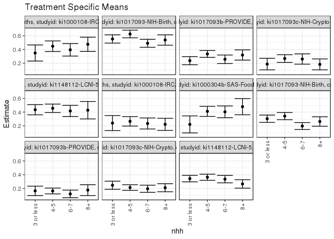

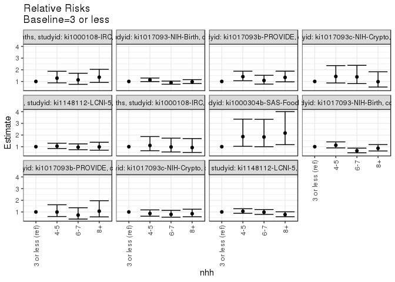

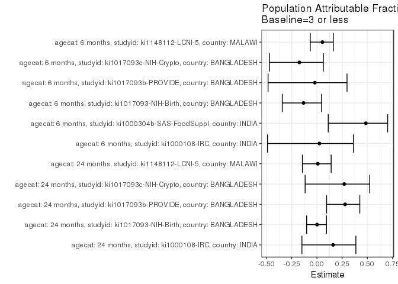

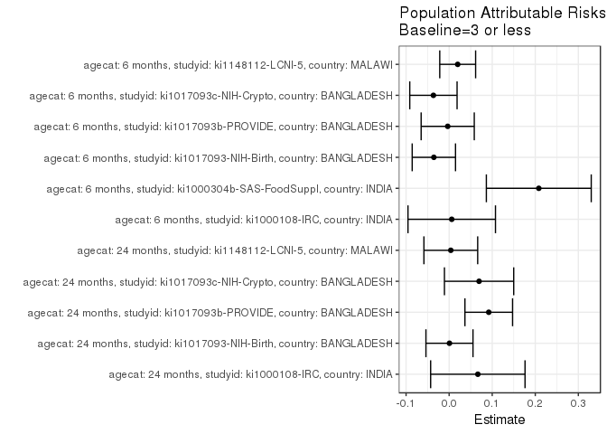

## Results Table

### Parameter: TSM

| agecat | studyid | country | intervention_level | baseline_level | estimate | ci_lower | ci_upper |
| --- | --- | --- | --- | --- | --- | --- | --- |
| 6 months | ki1000108-IRC | INDIA | 3 or less | NA | 0.2396875 | 0.1301014 | 0.3492735 |
| 6 months | ki1000108-IRC | INDIA | 4-5 | NA | 0.2649018 | 0.1961583 | 0.3336454 |
| 6 months | ki1000108-IRC | INDIA | 6-7 | NA | 0.2340343 | 0.1534258 | 0.3146427 |
| 6 months | ki1000108-IRC | INDIA | 8+ | NA | 0.2216522 | 0.1332798 | 0.3100247 |
| 6 months | ki1000304b-SAS-FoodSuppl | INDIA | 3 or less | NA | 0.2207731 | 0.0966335 | 0.3449126 |
| 6 months | ki1000304b-SAS-FoodSuppl | INDIA | 4-5 | NA | 0.4113217 | 0.3378634 | 0.4847800 |
| 6 months | ki1000304b-SAS-FoodSuppl | INDIA | 6-7 | NA | 0.4041408 | 0.3182874 | 0.4899942 |
| 6 months | ki1000304b-SAS-FoodSuppl | INDIA | 8+ | NA | 0.4790088 | 0.3610960 | 0.5969216 |
| 6 months | ki1017093-NIH-Birth | BANGLADESH | 3 or less | NA | 0.3036517 | 0.2507293 | 0.3565741 |
| 6 months | ki1017093-NIH-Birth | BANGLADESH | 4-5 | NA | 0.3418803 | 0.2891815 | 0.3945790 |
| 6 months | ki1017093-NIH-Birth | BANGLADESH | 6-7 | NA | 0.1966572 | 0.1462156 | 0.2470988 |
| 6 months | ki1017093-NIH-Birth | BANGLADESH | 8+ | NA | 0.2628054 | 0.1936900 | 0.3319207 |
| 6 months | ki1017093b-PROVIDE | BANGLADESH | 3 or less | NA | 0.1645613 | 0.0960048 | 0.2331178 |
| 6 months | ki1017093b-PROVIDE | BANGLADESH | 4-5 | NA | 0.1628934 | 0.1199692 | 0.2058176 |
| 6 months | ki1017093b-PROVIDE | BANGLADESH | 6-7 | NA | 0.1197598 | 0.0635042 | 0.1760154 |
| 6 months | ki1017093b-PROVIDE | BANGLADESH | 8+ | NA | 0.1753003 | 0.0963207 | 0.2542800 |
| 6 months | ki1017093c-NIH-Crypto | BANGLADESH | 3 or less | NA | 0.2463047 | 0.1866952 | 0.3059141 |
| 6 months | ki1017093c-NIH-Crypto | BANGLADESH | 4-5 | NA | 0.2125997 | 0.1716637 | 0.2535357 |
| 6 months | ki1017093c-NIH-Crypto | BANGLADESH | 6-7 | NA | 0.1949867 | 0.1427429 | 0.2472305 |
| 6 months | ki1017093c-NIH-Crypto | BANGLADESH | 8+ | NA | 0.2099632 | 0.1510535 | 0.2688730 |
| 6 months | ki1148112-LCNI-5 | MALAWI | 3 or less | NA | 0.3429045 | 0.2952239 | 0.3905851 |
| 6 months | ki1148112-LCNI-5 | MALAWI | 4-5 | NA | 0.3635402 | 0.3184541 | 0.4086264 |
| 6 months | ki1148112-LCNI-5 | MALAWI | 6-7 | NA | 0.3352970 | 0.2811799 | 0.3894141 |
| 6 months | ki1148112-LCNI-5 | MALAWI | 8+ | NA | 0.2657120 | 0.2043171 | 0.3271069 |
| 24 months | ki1000108-IRC | INDIA | 3 or less | NA | 0.3490165 | 0.2318134 | 0.4662197 |
| 24 months | ki1000108-IRC | INDIA | 4-5 | NA | 0.4479213 | 0.3707731 | 0.5250694 |
| 24 months | ki1000108-IRC | INDIA | 6-7 | NA | 0.3956585 | 0.3047849 | 0.4865320 |
| 24 months | ki1000108-IRC | INDIA | 8+ | NA | 0.4763648 | 0.3722463 | 0.5804833 |
| 24 months | ki1017093-NIH-Birth | BANGLADESH | 3 or less | NA | 0.5540304 | 0.4934675 | 0.6145934 |
| 24 months | ki1017093-NIH-Birth | BANGLADESH | 4-5 | NA | 0.6264105 | 0.5703994 | 0.6824215 |
| 24 months | ki1017093-NIH-Birth | BANGLADESH | 6-7 | NA | 0.4909639 | 0.4325224 | 0.5494054 |
| 24 months | ki1017093-NIH-Birth | BANGLADESH | 8+ | NA | 0.5390753 | 0.4636403 | 0.6145102 |
| 24 months | ki1017093b-PROVIDE | BANGLADESH | 3 or less | NA | 0.2373321 | 0.1780953 | 0.2965689 |
| 24 months | ki1017093b-PROVIDE | BANGLADESH | 4-5 | NA | 0.3352852 | 0.2849465 | 0.3856240 |
| 24 months | ki1017093b-PROVIDE | BANGLADESH | 6-7 | NA | 0.2577322 | 0.1956942 | 0.3197703 |
| 24 months | ki1017093b-PROVIDE | BANGLADESH | 8+ | NA | 0.3198721 | 0.2457887 | 0.3939555 |
| 24 months | ki1017093c-NIH-Crypto | BANGLADESH | 3 or less | NA | 0.1872991 | 0.1025959 | 0.2720022 |
| 24 months | ki1017093c-NIH-Crypto | BANGLADESH | 4-5 | NA | 0.2680042 | 0.2116340 | 0.3243744 |
| 24 months | ki1017093c-NIH-Crypto | BANGLADESH | 6-7 | NA | 0.2611608 | 0.1864546 | 0.3358670 |
| 24 months | ki1017093c-NIH-Crypto | BANGLADESH | 8+ | NA | 0.1829498 | 0.1033545 | 0.2625451 |
| 24 months | ki1148112-LCNI-5 | MALAWI | 3 or less | NA | 0.4351643 | 0.3606080 | 0.5097207 |
| 24 months | ki1148112-LCNI-5 | MALAWI | 4-5 | NA | 0.4557483 | 0.3941783 | 0.5173182 |
| 24 months | ki1148112-LCNI-5 | MALAWI | 6-7 | NA | 0.4171180 | 0.3352441 | 0.4989918 |
| 24 months | ki1148112-LCNI-5 | MALAWI | 8+ | NA | 0.4278147 | 0.3007636 | 0.5548657 |

### Parameter: E(Y)

| agecat | studyid | country | intervention_level | baseline_level | estimate | ci_lower | ci_upper |
| --- | --- | --- | --- | --- | --- | --- | --- |
| 6 months | ki1000108-IRC | INDIA | NA | NA | 0.2457002 | 0.2038248 | 0.2875757 |
| 6 months | ki1000304b-SAS-FoodSuppl | INDIA | NA | NA | 0.4289474 | 0.3791199 | 0.4787748 |
| 6 months | ki1017093-NIH-Birth | BANGLADESH | NA | NA | 0.2681564 | 0.2306532 | 0.3056597 |
| 6 months | ki1017093b-PROVIDE | BANGLADESH | NA | NA | 0.1612350 | 0.1313580 | 0.1911120 |
| 6 months | ki1017093c-NIH-Crypto | BANGLADESH | NA | NA | 0.2097902 | 0.1799252 | 0.2396552 |
| 6 months | ki1148112-LCNI-5 | MALAWI | NA | NA | 0.3627451 | 0.3297365 | 0.3957537 |
| 24 months | ki1000108-IRC | INDIA | NA | NA | 0.4156479 | 0.3678270 | 0.4634689 |
| 24 months | ki1017093-NIH-Birth | BANGLADESH | NA | NA | 0.5547786 | 0.5076945 | 0.6018626 |
| 24 months | ki1017093b-PROVIDE | BANGLADESH | NA | NA | 0.3292894 | 0.2909105 | 0.3676684 |
| 24 months | ki1017093c-NIH-Crypto | BANGLADESH | NA | NA | 0.2568093 | 0.2190047 | 0.2946140 |
| 24 months | ki1148112-LCNI-5 | MALAWI | NA | NA | 0.4390244 | 0.3983906 | 0.4796582 |

### Parameter: RR

| agecat | studyid | country | intervention_level | baseline_level | estimate | ci_lower | ci_upper |
| --- | --- | --- | --- | --- | --- | --- | --- |
| 6 months | ki1000108-IRC | INDIA | 3 or less | 3 or less | 1.0000000 | 1.0000000 | 1.0000000 |
| 6 months | ki1000108-IRC | INDIA | 4-5 | 3 or less | 1.1051966 | 0.6534888 | 1.8691364 |
| 6 months | ki1000108-IRC | INDIA | 6-7 | 3 or less | 0.9764142 | 0.5509500 | 1.7304379 |
| 6 months | ki1000108-IRC | INDIA | 8+ | 3 or less | 0.9247551 | 0.5041975 | 1.6961050 |
| 6 months | ki1000304b-SAS-FoodSuppl | INDIA | 3 or less | 3 or less | 1.0000000 | 1.0000000 | 1.0000000 |
| 6 months | ki1000304b-SAS-FoodSuppl | INDIA | 4-5 | 3 or less | 1.8630972 | 1.0336039 | 3.3582800 |
| 6 months | ki1000304b-SAS-FoodSuppl | INDIA | 6-7 | 3 or less | 1.8305712 | 1.0019572 | 3.3444452 |
| 6 months | ki1000304b-SAS-FoodSuppl | INDIA | 8+ | 3 or less | 2.1696884 | 1.1747336 | 4.0073322 |
| 6 months | ki1017093-NIH-Birth | BANGLADESH | 3 or less | 3 or less | 1.0000000 | 1.0000000 | 1.0000000 |
| 6 months | ki1017093-NIH-Birth | BANGLADESH | 4-5 | 3 or less | 1.1258961 | 0.8973607 | 1.4126336 |
| 6 months | ki1017093-NIH-Birth | BANGLADESH | 6-7 | 3 or less | 0.6476407 | 0.4780046 | 0.8774778 |
| 6 months | ki1017093-NIH-Birth | BANGLADESH | 8+ | 3 or less | 0.8654829 | 0.6339748 | 1.1815307 |
| 6 months | ki1017093b-PROVIDE | BANGLADESH | 3 or less | 3 or less | 1.0000000 | 1.0000000 | 1.0000000 |
| 6 months | ki1017093b-PROVIDE | BANGLADESH | 4-5 | 3 or less | 0.9898647 | 0.6063303 | 1.6160038 |
| 6 months | ki1017093b-PROVIDE | BANGLADESH | 6-7 | 3 or less | 0.7277521 | 0.3895775 | 1.3594807 |
| 6 months | ki1017093b-PROVIDE | BANGLADESH | 8+ | 3 or less | 1.0652587 | 0.5783575 | 1.9620669 |
| 6 months | ki1017093c-NIH-Crypto | BANGLADESH | 3 or less | 3 or less | 1.0000000 | 1.0000000 | 1.0000000 |
| 6 months | ki1017093c-NIH-Crypto | BANGLADESH | 4-5 | 3 or less | 0.8631575 | 0.6343861 | 1.1744281 |
| 6 months | ki1017093c-NIH-Crypto | BANGLADESH | 6-7 | 3 or less | 0.7916485 | 0.5522222 | 1.1348827 |
| 6 months | ki1017093c-NIH-Crypto | BANGLADESH | 8+ | 3 or less | 0.8524534 | 0.5891899 | 1.2333489 |
| 6 months | ki1148112-LCNI-5 | MALAWI | 3 or less | 3 or less | 1.0000000 | 1.0000000 | 1.0000000 |
| 6 months | ki1148112-LCNI-5 | MALAWI | 4-5 | 3 or less | 1.0601791 | 0.8819789 | 1.2743839 |
| 6 months | ki1148112-LCNI-5 | MALAWI | 6-7 | 3 or less | 0.9778143 | 0.7915276 | 1.2079437 |
| 6 months | ki1148112-LCNI-5 | MALAWI | 8+ | 3 or less | 0.7748862 | 0.5929649 | 1.0126208 |
| 24 months | ki1000108-IRC | INDIA | 3 or less | 3 or less | 1.0000000 | 1.0000000 | 1.0000000 |
| 24 months | ki1000108-IRC | INDIA | 4-5 | 3 or less | 1.2833812 | 0.8802057 | 1.8712300 |
| 24 months | ki1000108-IRC | INDIA | 6-7 | 3 or less | 1.1336382 | 0.7543681 | 1.7035922 |
| 24 months | ki1000108-IRC | INDIA | 8+ | 3 or less | 1.3648775 | 0.9147968 | 2.0363984 |
| 24 months | ki1017093-NIH-Birth | BANGLADESH | 3 or less | 3 or less | 1.0000000 | 1.0000000 | 1.0000000 |
| 24 months | ki1017093-NIH-Birth | BANGLADESH | 4-5 | 3 or less | 1.1306427 | 0.9889357 | 1.2926553 |
| 24 months | ki1017093-NIH-Birth | BANGLADESH | 6-7 | 3 or less | 0.8861677 | 0.7623614 | 1.0300800 |
| 24 months | ki1017093-NIH-Birth | BANGLADESH | 8+ | 3 or less | 0.9730066 | 0.8200938 | 1.1544312 |
| 24 months | ki1017093b-PROVIDE | BANGLADESH | 3 or less | 3 or less | 1.0000000 | 1.0000000 | 1.0000000 |
| 24 months | ki1017093b-PROVIDE | BANGLADESH | 4-5 | 3 or less | 1.4127259 | 1.0610393 | 1.8809806 |
| 24 months | ki1017093b-PROVIDE | BANGLADESH | 6-7 | 3 or less | 1.0859559 | 0.7723006 | 1.5269964 |
| 24 months | ki1017093b-PROVIDE | BANGLADESH | 8+ | 3 or less | 1.3477825 | 0.9654324 | 1.8815584 |
| 24 months | ki1017093c-NIH-Crypto | BANGLADESH | 3 or less | 3 or less | 1.0000000 | 1.0000000 | 1.0000000 |
| 24 months | ki1017093c-NIH-Crypto | BANGLADESH | 4-5 | 3 or less | 1.4308894 | 0.8682082 | 2.3582412 |
| 24 months | ki1017093c-NIH-Crypto | BANGLADESH | 6-7 | 3 or less | 1.3943520 | 0.8163729 | 2.3815313 |
| 24 months | ki1017093c-NIH-Crypto | BANGLADESH | 8+ | 3 or less | 0.9767790 | 0.5213191 | 1.8301596 |
| 24 months | ki1148112-LCNI-5 | MALAWI | 3 or less | 3 or less | 1.0000000 | 1.0000000 | 1.0000000 |
| 24 months | ki1148112-LCNI-5 | MALAWI | 4-5 | 3 or less | 1.0473016 | 0.8450233 | 1.2980004 |
| 24 months | ki1148112-LCNI-5 | MALAWI | 6-7 | 3 or less | 0.9585298 | 0.7409617 | 1.2399822 |
| 24 months | ki1148112-LCNI-5 | MALAWI | 8+ | 3 or less | 0.9831107 | 0.7000417 | 1.3806414 |

### Parameter: PAR

| agecat | studyid | country | intervention_level | baseline_level | estimate | ci_lower | ci_upper |
| --- | --- | --- | --- | --- | --- | --- | --- |
| 6 months | ki1000108-IRC | INDIA | 3 or less | NA | 0.0060128 | -0.0955562 | 0.1075818 |
| 6 months | ki1000304b-SAS-FoodSuppl | INDIA | 3 or less | NA | 0.2081743 | 0.0864163 | 0.3299323 |
| 6 months | ki1017093-NIH-Birth | BANGLADESH | 3 or less | NA | -0.0354953 | -0.0857950 | 0.0148044 |
| 6 months | ki1017093b-PROVIDE | BANGLADESH | 3 or less | NA | -0.0033263 | -0.0650016 | 0.0583490 |
| 6 months | ki1017093c-NIH-Crypto | BANGLADESH | 3 or less | NA | -0.0365144 | -0.0914407 | 0.0184118 |
| 6 months | ki1148112-LCNI-5 | MALAWI | 3 or less | NA | 0.0198406 | -0.0218016 | 0.0614827 |
| 24 months | ki1000108-IRC | INDIA | 3 or less | NA | 0.0666314 | -0.0429523 | 0.1762151 |
| 24 months | ki1017093-NIH-Birth | BANGLADESH | 3 or less | NA | 0.0007481 | -0.0538743 | 0.0553705 |
| 24 months | ki1017093b-PROVIDE | BANGLADESH | 3 or less | NA | 0.0919573 | 0.0366484 | 0.1472662 |
| 24 months | ki1017093c-NIH-Crypto | BANGLADESH | 3 or less | NA | 0.0695103 | -0.0109140 | 0.1499346 |
| 24 months | ki1148112-LCNI-5 | MALAWI | 3 or less | NA | 0.0038601 | -0.0585563 | 0.0662764 |

### Parameter: PAF

| agecat | studyid | country | intervention_level | baseline_level | estimate | ci_lower | ci_upper |
| --- | --- | --- | --- | --- | --- | --- | --- |
| 6 months | ki1000108-IRC | INDIA | 3 or less | NA | 0.0244719 | -0.4902899 | 0.3614296 |
| 6 months | ki1000304b-SAS-FoodSuppl | INDIA | 3 or less | NA | 0.4853143 | 0.1121710 | 0.7016302 |
| 6 months | ki1017093-NIH-Birth | BANGLADESH | 3 or less | NA | -0.1323678 | -0.3439226 | 0.0458849 |
| 6 months | ki1017093b-PROVIDE | BANGLADESH | 3 or less | NA | -0.0206302 | -0.4847134 | 0.2983926 |
| 6 months | ki1017093c-NIH-Crypto | BANGLADESH | 3 or less | NA | -0.1740522 | -0.4721504 | 0.0636837 |
| 6 months | ki1148112-LCNI-5 | MALAWI | 3 or less | NA | 0.0546956 | -0.0663567 | 0.1620061 |
| 24 months | ki1000108-IRC | INDIA | 3 or less | NA | 0.1603073 | -0.1489586 | 0.3863279 |
| 24 months | ki1017093-NIH-Birth | BANGLADESH | 3 or less | NA | 0.0013485 | -0.1020890 | 0.0950778 |
| 24 months | ki1017093b-PROVIDE | BANGLADESH | 3 or less | NA | 0.2792598 | 0.0960963 | 0.4253078 |
| 24 months | ki1017093c-NIH-Crypto | BANGLADESH | 3 or less | NA | 0.2706688 | -0.1170985 | 0.5238343 |
| 24 months | ki1148112-LCNI-5 | MALAWI | 3 or less | NA | 0.0087924 | -0.1440844 | 0.1412413 |